# Predicción de nacimientos en Colombia

# Visualización de resultados

Las visualizaciones son clave para entender el rendimiento de los modelos y la relación entre las predicciones y los valores reales. Se mostrarán gráficos comparando los nacimientos reales con los predichos para el conjunto de prueba, tanto a nivel nacional como para algunos departamentos seleccionados.

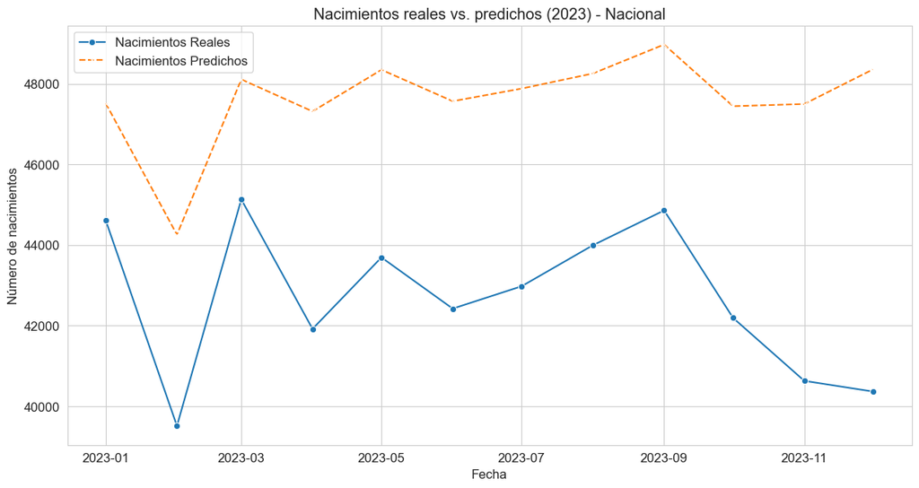

```python
# Combinar los valores reales y predichos para la visualización (Nacional)
results_national = test_data_national.copy()
results_national['predicted_births'] = y_pred_national

plt.figure(figsize=(14, 7))
sns.lineplot(x='date', y='total_births', data=results_national, label='Nacimientos Reales', marker='o')
sns.lineplot(x='date', y='predicted_births', data=results_national, label='Nacimientos Predichos', marker='x', linestyle='--')
plt.title('Nacimientos reales vs. predichos (2023) - Nacional')
plt.xlabel('Fecha')
plt.ylabel('Número de nacimientos')
plt.legend()
plt.grid(True)
plt.show()
```

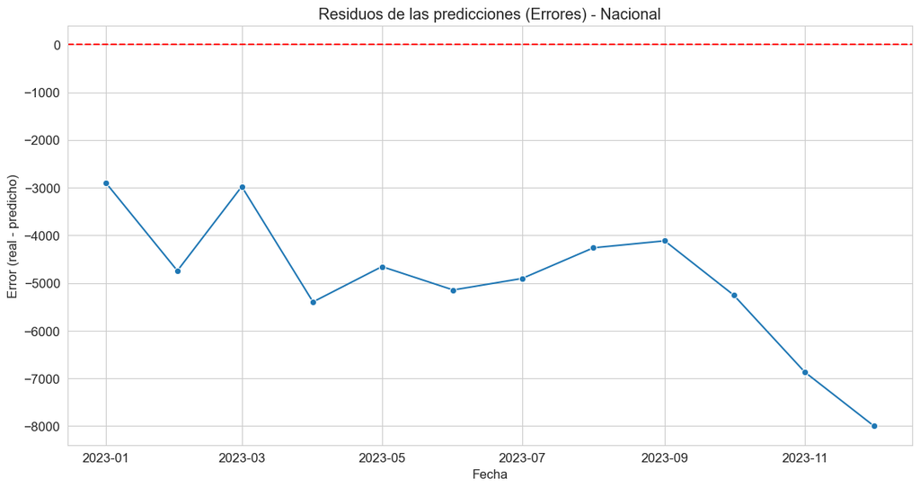

```python
# Visualización de los residuos (errores de predicción) (Nacional)
results_national['residuals'] = results_national['total_births'] - results_national['predicted_births']
plt.figure(figsize=(14, 7))
sns.lineplot(x='date', y='residuals', data=results_national, marker='o')
plt.axhline(0, color='red', linestyle='--')
plt.title('Residuos de las predicciones (Errores) - Nacional')
plt.xlabel('Fecha')
plt.ylabel('Error (real - predicho)')
plt.grid(True)
plt.show()
```

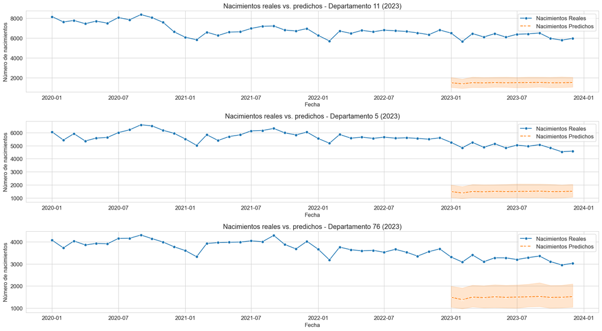

```python
# Combinamos los valores reales y predichos para la visualización (Departamental)
results_departmental = test_data_departmental.copy()
results_departmental['predicted_births'] = y_pred_departmental

# Unir los resultados predichos con el DataFrame original para tener COD_DPTO
results_departmental_with_cod = monthly_births_departmental.merge(
    results_departmental[['date', 'predicted_births']],
    on='date',
    how='left'
)

top_departments_for_plot = monthly_births_departmental.groupby('COD_DPTO', observed=False)['total_births'].sum().nlargest(3).index.tolist()
# Nacimientos reales vs. predichos - Departamento
plt.figure(figsize=(18, 10))
for i, dpto_code in enumerate(top_departments_for_plot):
    plt.subplot(3, 1, i + 1) # Ajusta el layout según el número de departamentos
    subset = results_departmental_with_cod[results_departmental_with_cod['COD_DPTO'] == dpto_code]
    sns.lineplot(x='date', y='total_births', data=subset, label='Nacimientos Reales', marker='o')
    sns.lineplot(x='date', y='predicted_births', data=subset, label='Nacimientos Predichos', marker='x', linestyle='--')
    plt.title(f'Nacimientos reales vs. predichos - Departamento {dpto_code} (2023)')
    plt.xlabel('Fecha')
    plt.ylabel('Número de nacimientos')
    plt.legend()
    plt.grid(True)
plt.tight_layout()
plt.show()
```

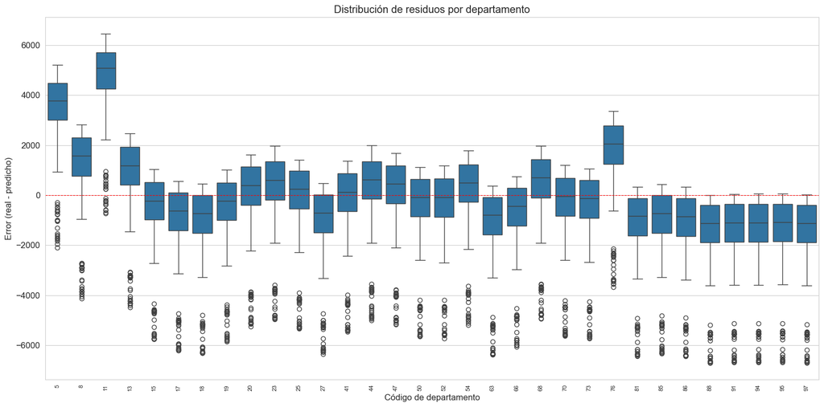

```python
# Visualización de los residuos (errores de predicción) por departamento
results_departmental_with_cod['residuals'] = results_departmental_with_cod['total_births'] - results_departmental_with_cod['predicted_births']

plt.figure(figsize=(16, 8))
sns.boxplot(x='COD_DPTO', y='residuals', data=results_departmental_with_cod)
plt.axhline(0, color='red', linestyle='--', linewidth=0.8)
plt.title('Distribución de residuos por departamento')
plt.xlabel('Código de departamento')
plt.ylabel('Error (real - predicho)')
plt.xticks(rotation=90, fontsize=8)
plt.tight_layout()
plt.show()
```

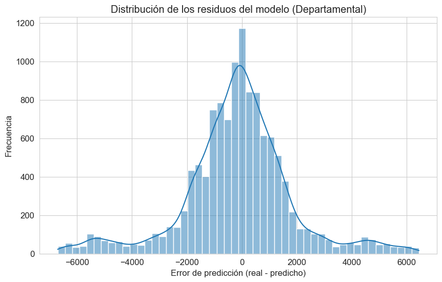

```python
# Histograma de residuos para ver la distribución de errores (Departamental)
plt.figure(figsize=(10, 6))
sns.histplot(results_departmental_with_cod['residuals'], bins=50, kde=True)
plt.title('Distribución de los residuos del modelo (Departamental)')
plt.xlabel('Error de predicción (real - predicho)')
plt.ylabel('Frecuencia')
plt.grid(True)
plt.show()
```

# Conclusiones

## Posibles mejoras futuras:

- Ampliar series históricas: Obtener y utilizar datos de nacimientos de más años anteriores para ambos niveles de análisis.
- Incorporar Variables Externas: Incluir características como indicadores económicos (PIB, desempleo), políticas de salud, eventos demográficos (migración), y variables específicas de cada departamento (ej. tasa de pobreza departamental, acceso a servicios de salud, etc.).
- Modelos específicos por departamento: Si el rendimiento del modelo departamental global no es suficiente para ciertos departamentos clave, considerar entrenar modelos individuales para esas regiones con dinámicas muy particulares.
- Modelos jerárquicos o multi-serie: Explorar técnicas más avanzadas diseñadas para pronóstico de múltiples series temporales relacionadas, como modelos jerárquicos que modelan la relación entre el total nacional y los departamentos, o modelos de series temporales multivariadas.
- Modelos de series temporales avanzados: Explorar modelos como ARIMA, SARIMA, Prophet o redes neuronales recurrentes (RNNs) que están diseñados específicamente para datos de series temporales y pueden capturar dependencias temporales más complejas.
- Optimización de hiperparámetros: Realizar una búsqueda de hiperparámetros (ej. GridSearchCV, RandomizedSearchCV) para los RandomForestRegressor o cualquier otro modelo elegido para encontrar la configuración óptima.

# Referencias

- pandas development team. (s.f.). *pandas: Powerful data analysis toolkit*. Recuperado de https://pandas.pydata.org/
- NumPy developers. (s.f.). *NumPy*. Recuperado de https://numpy.org/
- Matplotlib. (s.f.). *Matplotlib: Python Plotting*. Recuperado de https://matplotlib.org/
- Seaborn developers. (s.f.). *seaborn: statistical data visualization*. Recuperado de https://seaborn.pydata.org/
- scikit-learn developers. (s.f.). *scikit-learn: machine learning in Python*. Recuperado de https://scikit-learn.org/stable/

# Diccionario de Datos de Variables DANE

Esta sección contiene la descripción y los valores de las variables obtenidas de los microdatos del DANE.

## Variable: COD_DPTO

- **Etiqueta**: Departamento de Nacimiento
- **Preguntas del Cuestionario**: Departamento de Nacimiento  
  Código, según la División Político- Administrativa del DANE.  
  05= Antioquia  
  08= Atlántico  
  11= Bogotá  
  13= Bolivar  
  15= Boyaca  
  17=Caldas  
  18= Caqueta  
  19=Cauca  
  20= Cesar  
  23= Cordoba  
  25=Cundinamarca  
  27= Choco  
  41= Huila  
  44= La guajira  
  47= Magdalena  
  50= Meta  
  52= Nariño  
  54= Norte de Santander  
  63= Quindio  
  66= Risaralda  
  68= Santander  
  70= Sucre  
  73= Tolima  
  76= Valle del Cauca  
  81= Arauca  
  85= Casanare  
  86= Putumayo  
  88= Archipiélago de San Andrés, Providencia y Santa Catalina  
  91= Amazonas  
  94= Guainía  
  95= Guaviare  
  97= Vaupés  
  99= Vichada

### Tabla de Categorías:

| Código | Etiqueta | Frecuencia |
| --- | --- | --- |
| 05 | Antioquia | 59311 |
| 08 | Atlántico | 32872 |
| 11 | Bogotá | 74286 |
| 13 | Bolivar | 28222 |
| 15 | Boyaca | 11597 |
| 17 | Caldas | 6666 |
| 18 | Caqueta | 5225 |
| 19 | Cauca | 11414 |
| 20 | Cesar | 18975 |
| 23 | Cordoba | 21444 |
| 25 | Cundinamarca | 16982 |
| 27 | Choco | 5800 |
| 41 | Huila | 15688 |
| 44 | La guajira | 22166 |
| 47 | Magdalena | 19443 |
| 50 | Meta | 13160 |
| 52 | Nariño | 13119 |
| 54 | Norte de Santander | 20112 |
| 63 | Quindio | 4452 |
| 66 | Risaralda | 8885 |
| 68 | Santander | 22404 |
| 70 | Sucre | 13531 |
| 73 | Tolima | 12419 |
| 76 | Valle del Cauca | 38397 |
| 81 | Arauca | 3936 |
| 85 | Casanare | 5227 |
| 86 | Putumayo | 3798 |
| 88 | Archipiélago de San Andrés, Providencia y Santa Catalina | 567 |
| 91 | Amazonas | 938 |
| 94 | Guainía | 1059 |
| 95 | Guaviare | 1154 |
| 97 | Vaupés | 688 |
| 99 | Vichada | 1612 |

## Variable: COD_MUNIC

- **Etiqueta**: Municipio de Nacimiento
- **Preguntas del Cuestionario**: Municipio de Nacimiento  
  Código, según la División Político- Administrativa del DANE.

### Tabla de Categorías:

[output not shown]

[output cut: 506 more lines]

## Variable: AREANAC

- **Etiqueta**: Área del Nacimiento
- **Preguntas del Cuestionario**: Área del Nacimiento  
  1 = Cabecera municipal  
  2 = Centro poblado (Inspección, corregimiento o caserío)  
  3 = Rural disperso  
  9 = Sin información

### Tabla de Categorías:

| Código | Etiqueta | Frecuencia |
| --- | --- | --- |
| 1 | Cabecera municipal | 503538 |
| 2 | Centro poblado (Inspección, corregimiento o caserío) | 2543 |
| 3 | Rural disperso | 5382 |
| 9 | Sin información | 4086 |

## Variable: SIT_PARTO

- **Etiqueta**: Sitio de la Parto
- **Preguntas del Cuestionario**: Sitio de la Parto  
  1 = Institución de salud  
  2 = Domicilio  
  3 = Otro  
  9 = Sin información

### Tabla de Categorías:

| Código | Etiqueta | Frecuencia |
| --- | --- | --- |
| 1 | Institución de salud | 503611 |
| 2 | Domicilio | 6815 |
| 3 | Otro | 1037 |
| 9 | Sin información | 4086 |

## Variable: OTRO_SIT

- **Etiqueta**: Otro sitio, ¿cuál?
- **Preguntas del Cuestionario**: Otro sitio, ¿cuál?

### Tabla de Categorías:

[output not shown]

[output cut: 510 more lines]

## Variable: SEXO

- **Etiqueta**: Sexo del nacido vivo
- **Preguntas del Cuestionario**: Sexo del nacido vivo  
  1 = Masculino  
  2 = Femenino  
  3= Indeterminado

### Tabla de Categorías:

| Código | Etiqueta | Frecuencia |
| --- | --- | --- |
| 1 | Masculino | 264580 |
| 2 | Femenino | 250932 |
| 3 | Indeterminado | 37 |

## Variable: PESO_NAC

- **Etiqueta**: Peso del nacido vivo, al nacer
- **Preguntas del Cuestionario**: Peso del nacido vivo, al nacer  
  1 = Menos de 1.000  
  2 = 1.000 - 1.499  
  3 = 1.500 - 1.999  
  4 = 2.000 - 2499  
  5 = 2.500 - 2.999  
  6 = 3.000 - 3499  
  7 = 3.500 - 3.999  
  8 = 4.000 y más  
  9 = Sin información

### Tabla de Categorías:

| Código | Etiqueta | Frecuencia |
| --- | --- | --- |
| 1 | Menos de 1.000 | 2154 |
| 2 | 1.000 - 1.499 | 4133 |
| 3 | 1.500 - 1.999 | 9847 |
| 4 | 2.000 - 2499 | 39896 |
| 5 | 2.500 - 2.999 | 154058 |
| 6 | 3.000 - 3499 | 212958 |
| 7 | 3.500 - 3.999 | 76427 |
| 8 | 4.000 y más | 9508 |
| 9 | Sin información | 6568 |

## Variable: TALLA_NAC

- **Etiqueta**: Talla del nacido vivo, al nacer
- **Preguntas del Cuestionario**: Talla del nacido vivo, al nacer  
  1 = Menos de 20  
  2 = 20-29  
  3 = 30-39  
  4 = 40-49  
  5 = 50-59  
  6 = 60 y Más.  
  9 = Sin información

### Tabla de Categorías:

| Código | Etiqueta | Frecuencia |
| --- | --- | --- |
| 1 | Menos de 20 | 4 |
| 2 | 20-29 | 307 |
| 3 | 30-39 | 5075 |
| 4 | 40-49 | 236277 |
| 5 | 50-59 | 267249 |
| 6 | 60 y Más. | 20 |
| 9 | Sin información | 6617 |

## Variable: ANO

- **Etiqueta**: Año de la ocurrencia
- **Preguntas del Cuestionario**: Año de la ocurrencia  
  2023

### Tabla de Categorías:

| Código | Etiqueta | Frecuencia |
| --- | --- | --- |
| 2023 | None | 515549 |

## Variable: MES

- **Etiqueta**: Mes de la ocurrencia
- **Preguntas del Cuestionario**: Mes de la ocurrencia  
  01 = Enero  
  02 = Febrero  
  03 = Marzo  
  04 = Abril  
  05 = Mayo  
  06 = Junio  
  07 = Julio  
  08 = Agosto  
  09 = Septiembre  
  10 = Octubre  
  11 = Noviembre  
  12 = Diciembre

### Tabla de Categorías:

| Código | Etiqueta | Frecuencia |
| --- | --- | --- |
| 01 | Enero | 45020 |
| 02 | Febrero | 39813 |
| 03 | Marzo | 45529 |
| 04 | Abril | 42198 |
| 05 | Mayo | 44045 |
| 06 | Junio | 42745 |
| 07 | Julio | 43241 |
| 08 | Agosto | 44220 |
| 09 | Septiembre | 45046 |
| 10 | Octubre | 42396 |
| 11 | Noviembre | 40782 |
| 12 | Diciembre | 40514 |

## Variable: ATEN_PAR

- **Etiqueta**: El parto fue atendido por
- **Preguntas del Cuestionario**: El parto fue atendido por  
  1 = Médico  
  2 = Enfermero(a)  
  3 = Auxiliar de enfermería  
  4 = Promotor(a) de salud  
  5 = Partera  
  6 = Otro persona  
  9 = Sin información

### Tabla de Categorías:

| Código | Etiqueta | Frecuencia |
| --- | --- | --- |
| 1 | Médico | 503663 |
| 2 | Enfermero(a) | 372 |
| 3 | Auxiliar de enfermería | 328 |
| 4 | Promotor(a) de salud | 78 |
| 5 | Partera | 4243 |
| 6 | Otro persona | 2779 |
| 9 | Sin información | 4086 |

## Variable: T_GES

- **Etiqueta**: Tiempo de gestación del nacido vivo
- **Preguntas del Cuestionario**: Tiempo de gestación del nacido vivo  
  1 = Menos de 22  
  2 = De 22 a 27  
  3 = De 28 a 37  
  4 = De 38 a 41  
  5 = De 42 y más  
  6 = Ignorado  
  9 = Sin información

### Tabla de Categorías:

| Código | Etiqueta | Frecuencia |
| --- | --- | --- |
| 1 | Menos de 22 | 19 |
| 2 | De 22 a 27 | 1959 |
| 3 | De 28 a 37 | 134646 |
| 4 | De 38 a 41 | 372000 |
| 5 | De 42 y más | 483 |
| 6 | Ignorado | 6337 |
| 9 | Sin información | 105 |

## Variable: T_GES_AGRU_CIE

- **Etiqueta**: Tiempo de gestación del nacido vivo ajustado a la agrupación sugerida por la CIE
- **Preguntas del Cuestionario**: Tiempo de gestación del nacido vivo ajustado a la agrupación sugerida por la CIE  
  1 = Menos de 22  
  2 = De 22 a 27  
  3 = De 28 a 36  
  4 = De 37 a 41  
  5 = De 42 y más  
  6 = Ignorado  
  9 = Sin información

### Tabla de Categorías:

| Código | Etiqueta | Frecuencia |
| --- | --- | --- |
| 1 | Menos de 22 | 19 |
| 2 | De 22 a 27 | 1959 |
| 3 | De 28 a 36 | 54674 |
| 4 | De 37 a 41 | 451972 |
| 5 | De 42 y más | 483 |
| 6 | Ignorado | 6337 |
| 9 | Sin información | 105 |

## Variable: NUMCONSUL

- **Etiqueta**: Número de consultas prenatales que tuvo la madre del nacido vivo
- **Preguntas del Cuestionario**: Número de consultas prenatales que tuvo la madre del nacido vivo  
  00= Ninguna  
  99 = Sin información

### Tabla de Categorías:

| Código | Etiqueta | Frecuencia |
| --- | --- | --- |
| 00 | Ninguna | 17062 |
| 01 | None | 10874 |
| 02 | None | 16616 |
| 03 | None | 25135 |
| 04 | None | 38972 |
| 05 | None | 65605 |
| 06 | None | 76016 |
| 07 | None | 85645 |
| 08 | None | 88169 |
| 09 | None | 43835 |
| 10 | None | 26073 |
| 11 | None | 4945 |
| 12 | None | 6132 |
| 13 | None | 1532 |
| 14 | None | 1189 |
| 15 | None | 1816 |
| 16 | None | 468 |
| 17 | None | 171 |
| 18 | None | 229 |
| 19 | None | 44 |
| 20 | None | 428 |
| 21 | None | 19 |
| 22 | None | 23 |
| 23 | None | 19 |
| 24 | None | 14 |
| 25 | None | 33 |
| 99 | Sin información | 4485 |

## Variable: TIPO_PARTO

- **Etiqueta**: Tipo de parto de este nacimiento
- **Preguntas del Cuestionario**: Tipo de parto de este nacimiento  
  1 = Espontáneo  
  2 = Cesárea  
  3 = Instrumentado  
  4 = Ignorado  
  9 = Sin información

### Tabla de Categorías:

| Código | Etiqueta | Frecuencia |
| --- | --- | --- |
| 1 | Espontáneo | 249961 |
| 2 | Cesárea | 255471 |
| 3 | Instrumentado | 5632 |
| 4 | Ignorado | 0 |
| 9 | Sin información | 4485 |

## Variable: MUL_PARTO

- **Etiqueta**: Multiplicidad del embarazo
- **Preguntas del Cuestionario**: Multiplicidad del embarazo  
  1 = Simple  
  2 = Doble  
  3 = Triple  
  4 = Cuádruple o más  
  9 = Sin información

### Tabla de Categorías:

| Código | Etiqueta | Frecuencia |
| --- | --- | --- |
| 1 | Simple | 501874 |
| 2 | Doble | 9101 |
| 3 | Triple | 102 |
| 4 | Cuádruple o más | 5 |
| 9 | Sin información | 4467 |

## Variable: APGAR1

- **Etiqueta**: APGAR al minuto del nacido vivo
- **Preguntas del Cuestionario**: APGAR al minuto del nacido vivo  
  01 - 10 = Al minuto  
  99 = sin información

### Tabla de Categorías:

| Código | Etiqueta | Frecuencia |
| --- | --- | --- |
| 01 | Al minuto | 481 |
| 02 | Al minuto | 301 |
| 03 | Al minuto | 608 |
| 04 | Al minuto | 896 |
| 05 | Al minuto | 2322 |
| 06 | Al minuto | 3614 |
| 07 | Al minuto | 15204 |
| 08 | Al minuto | 104424 |
| 09 | Al minuto | 222957 |
| 10 | Al minuto | 152804 |
| 99 | Sin información | 11938 |

## Variable: APGAR2

- **Etiqueta**: APGAR a los cinco minutos del nacido vivo
- **Preguntas del Cuestionario**: APGAR a los cinco minutos del nacido vivo  
  01 - 10 = A los cinco minutos  
  99 = sin información

### Tabla de Categorías:

| Código | Etiqueta | Frecuencia |
| --- | --- | --- |
| 01 | A los cinco minutos | 428 |
| 02 | A los cinco minutos | 158 |
| 03 | A los cinco minutos | 278 |
| 04 | A los cinco minutos | 457 |
| 05 | A los cinco minutos | 1266 |
| 06 | A los cinco minutos | 1936 |
| 07 | A los cinco minutos | 6040 |
| 08 | A los cinco minutos | 29257 |
| 09 | A los cinco minutos | 249720 |
| 10 | A los cinco minutos | 214071 |
| 99 | Sin información | 11938 |

## Variable: IDHEMOCLAS

- **Etiqueta**: Hemoclasificación del nacido vivo: Grupo Sanguíneo
- **Preguntas del Cuestionario**: Hemoclasificación del nacido vivo: Grupo Sanguíneo  
  1 = A  
  2 = B  
  3 = O  
  4 = AB  
  9 = Sin información

### Tabla de Categorías:

| Código | Etiqueta | Frecuencia |
| --- | --- | --- |
| 1 | A | 128160 |
| 2 | B | 47303 |
| 3 | O | 326605 |
| 4 | AB | 8884 |
| 9 | Sin información | 4597 |

## Variable: IDFACTORRH

- **Etiqueta**: Hemoclasificación del nacido vivo: Factor RH
- **Preguntas del Cuestionario**: Hemoclasificación del nacido vivo: Factor RH  
  1 = Positivo  
  2 = Negativo  
  9= Sin información

### Tabla de Categorías:

| Código | Etiqueta | Frecuencia |
| --- | --- | --- |
| 1 | Positivo | 487198 |
| 2 | Negativo | 23748 |
| 9 | Sin información | 4603 |

## Variable: IDPERTET

- **Etiqueta**: De acuerdo con la cultura, pueblo o rasgos físicos, el nacido vivo es reconocido por sus padres como
- **Preguntas del Cuestionario**: De acuerdo con la cultura, pueblo o rasgos físicos, el nacido vivo es reconocido por sus padres como  
  1 = Indígena  
  2 = Rom (Gitano)  
  3 = Raizal del archipiélago de San Andrés y Providencia  
  4 = Palenquero de San Basilio  
  5 = Negro(a), mulato(a), afrocolombiano(a) o afrodescendiente  
  6 = Ninguna de las anteriores  
  9 = Sin información

### Tabla de Categorías:

| Código | Etiqueta | Frecuencia |
| --- | --- | --- |
| 1 | Indígena | 27068 |
| 2 | Rom (Gitano) | 26 |
| 3 | Raizal del archipiélago de San Andrés y Providencia | 306 |
| 4 | Palenquero de San Basilio | 34 |
| 5 | Negro(a), mulato(a), afrocolombiano(a) o afrodescendiente | 19382 |
| 6 | Ninguna de las anteriores | 464647 |
| 9 | Sin información | 4086 |

## Variable: EDAD_MADRE

- **Etiqueta**: Edad de la madre a la fecha del parto
- **Preguntas del Cuestionario**: Edad de la madre a la fecha del parto  
  1 = De 10-14 Años  
  2 = De 15-19 Años  
  3 = De 20-24 Años  
  4 = De 25-29 Años  
  5 = De 30-34 Años  
  6 = De 35-39 Años  
  7 = De 40-44 Años  
  8 = De 45-49 Años  
  9 = De 50-54 Años  
  99 = Sin información

### Tabla de Categorías:

| Código | Etiqueta | Frecuencia |
| --- | --- | --- |
| 1 | De 10-14 Años | 3837 |
| 2 | De 15-19 Años | 78617 |
| 3 | De 20-24 Años | 138341 |
| 4 | De 25-29 Años | 132592 |
| 5 | De 30-34 Años | 96828 |
| 6 | De 35-39 Años | 50246 |
| 7 | De 40-44 Años | 13723 |
| 8 | De 45-49 Años | 955 |
| 9 | De 50-54 Años | 47 |
| 99 | Sin información | 363 |

## Variable: EST_CIVM

- **Etiqueta**: Estado conyugal de la madre
- **Preguntas del Cuestionario**: Estado conyugal de la madre  
  1 = No está casada y lleva dos o más años viviendo con su pareja  
  2 = No está casada y lleva menos de dos años viviendo con su pareja  
  3 = Está separada, divorciada  
  4 = Está viuda  
  5 = Está soltera  
  6 = Está casada  
  9 = Sin información

### Tabla de Categorías:

| Código | Etiqueta | Frecuencia |
| --- | --- | --- |
| 1 | No está casada y lleva dos o más años viviendo con su pareja | 285121 |
| 2 | No está casada y lleva menos de dos años viviendo con su pareja | 87664 |
| 3 | Está separada, divorciada | 1200 |
| 4 | Está viuda | 378 |
| 5 | Está soltera | 61486 |
| 6 | Está casada | 65258 |
| 9 | Sin información | 14442 |

## Variable: NIV_EDUM

- **Etiqueta**: Ultimo nivel de estudio que aprobó la madre
- **Preguntas del Cuestionario**: Nivel educativo del la madre  
  1 = Preescolar  
  2 = Básica primaria  
  3 = Básica secundaria  
  4 = Media académica o clásica  
  5 = Media técnica  
  6 = Normalista  
  7 = Técnica profesional  
  8 = Tecnológica  
  9 = Profesional  
  10 = Especialización  
  11 = Maestría  
  12 = Doctorado  
  13 = Ninguno  
  99 = Sin información

### Tabla de Categorías:

| Código | Etiqueta | Frecuencia |
| --- | --- | --- |
| 01 | Preescolar | 649 |
| 02 | Básica primaria | 51931 |
| 03 | Básica secundaria | 107633 |
| 04 | Media académica o clásica | 173292 |
| 05 | Media técnica | 10490 |
| 06 | Normalista | 633 |
| 07 | Técnica profesional | 45587 |
| 08 | Tecnológica | 28866 |
| 09 | Profesional | 63120 |
| 10 | Especialización | 7458 |
| 11 | Maestría | 2464 |
| 12 | Doctorado | 115 |
| 13 | Ninguno | 5323 |
| 99 | Sin información | 17988 |

## Variable: ULTCURMAD

- **Etiqueta**: Ultimo año o grado aprobado de la madre
- **Preguntas del Cuestionario**: Ultimo año o grado aprobado de la madre  
  99 = Sin información.

### Tabla de Categorías:

| Código | Etiqueta | Frecuencia |
| --- | --- | --- |
| 99 | Sin información. | 17988 |

## Variable: CODPRES

- **Etiqueta**: País de residencia habitual de la madre en el extranjero
- **Preguntas del Cuestionario**: País de residencia habitual de la madre en el extranjero  
  Código, según listado de países ISO 3166/2

### Tabla de Categorías:

| Código | Etiqueta | Frecuencia |
| --- | --- | --- |
| " | None | 4088 |
| 068 | None | 1 |
| 076 | None | 42 |
| 152 | None | 2 |
| 170 | Colombia | 508299 |
| 214 | None | 1 |
| 218 | None | 18 |
| 276 | None | 2 |
| 320 | None | 2 |
| 324 | None | 1 |
| 332 | None | 2 |
| 380 | None | 1 |
| 422 | None | 1 |
| 430 | None | 1 |
| 484 | None | 1 |
| 531 | None | 1 |
| 533 | None | 17 |
| 591 | None | 2 |
| 604 | None | 16 |
| 608 | None | 1 |
| 630 | None | 2 |
| 660 | None | 1 |
| 724 | None | 1 |
| 840 | None | 2 |
| 862 | None | 3044 |

## Variable: CODPTORE

- **Etiqueta**: Departamento de residencia habitual de la madre
- **Preguntas del Cuestionario**: Departamento de residencia habitual de la madre  
  Código, según la División Político- Administrativa del DANE.

### Tabla de Categorías:

| Código | Etiqueta | Frecuencia |
| --- | --- | --- |
| " | None | 7250 |
| 05 | Antioquia | 59017 |
| 08 | Atlántico | 31727 |
| 11 | Bogotá | 60912 |
| 13 | Bolivar | 29953 |
| 15 | Boyaca | 11327 |
| 17 | Caldas | 6704 |
| 18 | Caqueta | 5137 |
| 19 | Cauca | 14115 |
| 20 | Cesar | 18144 |
| 23 | Cordoba | 21080 |
| 25 | Cundinamarca | 29061 |
| 27 | Choco | 6642 |
| 41 | Huila | 15148 |
| 44 | La guajira | 20333 |
| 47 | Magdalena | 19865 |
| 50 | Meta | 12989 |
| 52 | Nariño | 12610 |
| 54 | Norte de Santander | 18974 |
| 63 | Quindio | 4224 |
| 66 | Risaralda | 8196 |
| 68 | Santander | 21890 |
| 70 | Sucre | 11986 |
| 73 | Tolima | 13073 |
| 76 | Valle del Cauca | 36514 |
| 81 | Arauca | 3482 |
| 85 | Casanare | 5429 |
| 86 | Putumayo | 3997 |
| 88 | Archipiélago de San Andrés, Providencia y Santa Catalina | 608 |
| 91 | Amazonas | 903 |
| 94 | Guainía | 738 |
| 95 | Guaviare | 1131 |
| 97 | Vaupés | 690 |
| 99 | Vichada | 1700 |

## Variable: CODMUNRE

- **Etiqueta**: Municipio de residencia habitual de la madre
- **Preguntas del Cuestionario**: Municipio de residencia habitual de la madre  
  Municipio de residencia habitual, según la División Político- Administrativa del DANE

### Tabla de Categorías:

[output not shown]

[output cut: 551 more lines]

## Variable: AREA_RES

- **Etiqueta**: Área de residencia habitual de la madre
- **Preguntas del Cuestionario**: Área de residencia habitual de la madre  
  1 = Cabecera municipal  
  2 = Centro poblado (inspección, corregimiento o caserío)  
  3 = Rural disperso  
  9 = Sin información

### Tabla de Categorías:

| Código | Etiqueta | Frecuencia |
| --- | --- | --- |
| " | None | 7250 |
| 1 | Cabecera municipal | 378914 |
| 2 | Centro poblado (inspección, corregimiento o caserío) | 34980 |
| 3 | Rural disperso | 94405 |
| 9 | Sin información | 0 |

## Variable: N_HIJOSV

- **Etiqueta**: Número de hijos nacidos vivos que ha tenido la madre, incluido el presente
- **Preguntas del Cuestionario**: Número de hijos nacidos vivos que ha tenido la madre, incluido el presente  
  1 = 1 hijo  
  2 = 2 hijos  
  3 = 3 hijos  
  4 = 4 hijos  
  5 = 5 hijos  
  6 = 6 hijos  
  7 = 7 hijos  
  8 = 8 hijos  
  9 = 9 hijos  
  10 = 10 hijos  
  11 = 11 hijos  
  12 = 12 hijos  
  13 = 13 hijos  
  14 = 14 hijos  
  15 = 15 hijos  
  16 = 16 hijos  
  17 = 17 hijos  
  18 = 18 hijos  
  19 = 19 hijos  
  20 = 20 hijos  
  21 = 21 hijos  
  22 = 22 hijos  
  99 = Sin información

### Tabla de Categorías:

| Código | Etiqueta | Frecuencia |
| --- | --- | --- |
| 1 | 1 hijo | 235780 |
| 2 | 2 hijos | 168493 |
| 3 | 3 hijos | 67521 |
| 4 | 4 hijos | 21940 |
| 5 | 5 hijos | 8808 |
| 6 | 6 hijos | 4342 |
| 7 | 7 hijos | 2096 |
| 8 | 8 hijos | 1053 |
| 9 | 9 hijos | 562 |
| 10 | 10 hijos | 250 |
| 11 | 11 hijos | 111 |
| 12 | 12 hijos | 66 |
| 13 | 13 hijos | 28 |
| 14 | 14 hijos | 8 |
| 15 | 15 hijos | 4 |
| 16 | 16 hijos | 1 |
| 17 | 17 hijos | 1 |
| 18 | 18 hijos | 0 |
| 19 | 19 hijos | 0 |
| 20 | 20 hijos | 0 |
| 21 | 21 hijos | 0 |
| 22 | 22 hijos | 0 |
| 99 | Sin información | 4485 |

## Variable: FECHA_NACM

- **Etiqueta**: Fecha de nacimiento del anterior hijo nacido vivo
- **Preguntas del Cuestionario**: Fecha de nacimiento del anterior hijo nacido vivo

### Tabla de Categorías:

| Código | Etiqueta | Frecuencia |
| --- | --- | --- |
| NA | NA | NA |

## Variable: N_EMB

- **Etiqueta**: Número de embarazos, incluido el presente
- **Preguntas del Cuestionario**: Número de embarazos, incluido el presente  
  99 = Sin información

### Tabla de Categorías:

| Código | Etiqueta | Frecuencia |
| --- | --- | --- |
| 99 | Sin información | 4491 |

## Variable: SEG_SOCIAL

- **Etiqueta**: Régimen de seguridad social en salud de la madre
- **Preguntas del Cuestionario**: Régimen de seguridad social en salud de la madre  
  1 = Contributivo  
  2 = Subsidiado  
  3 = Excepción  
  4 = Especial  
  5 = No asegurado  
  9 = Sin información

### Tabla de Categorías:

| Código | Etiqueta | Frecuencia |
| --- | --- | --- |
| 1 | Contributivo | 191858 |
| 2 | Subsidiado | 290602 |
| 3 | Excepción | 4864 |
| 4 | Especial | 102 |
| 5 | No asegurado | 23638 |
| 9 | Sin información | 4485 |

## Variable: IDCLASADMI

- **Etiqueta**: Entidad Administradora en Salud a la que pertenece la madre
- **Preguntas del Cuestionario**: Entidad Administradora en Salud a la que pertenece la madre  
  1 = Entidad promotora de salud  
  2 = Entidad promotora de salud - Subsidiado  
  3 = Entidad adaptada de salud  
  4 = Entidad especial de salud  
  5 = Entidad exceptuada de salud  
  9 = Sin información

### Tabla de Categorías:

| Código | Etiqueta | Frecuencia |
| --- | --- | --- |
| " | None | 23638 |
| 1 | Entidad promotora de salud | 191858 |
| 2 | Entidad promotora de salud - Subsidiado | 290602 |
| 3 | Entidad adaptada de salud | 0 |
| 4 | Entidad especial de salud | 102 |
| 5 | Entidad exceptuada de salud | 4864 |
| 9 | Sin información | 4485 |

## Variable: EDAD_PADRE

- **Etiqueta**: Edad del padre en años cumplidos a la fecha del nacimiento de este hijo
- **Preguntas del Cuestionario**: Edad del padre en años cumplidos a la fecha del nacimiento de este hijo  
  999 = Sin información

### Tabla de Categorías:

| Código | Etiqueta | Frecuencia |
| --- | --- | --- |
| 999 | Sin información | 6282 |

## Variable: ULTCURPAD

- **Etiqueta**: Ultimo año o grado aprobado del padre
- **Preguntas del Cuestionario**: Último año o grado aprobado del nivel educativo del padre  
  99 = Sin información

### Tabla de Categorías:

| Código | Etiqueta | Frecuencia |
| --- | --- | --- |
| 99 | Sin información | 48515 |

## Variable: PROFESION

- **Etiqueta**: Profesión de quien certifica el nacimiento
- **Preguntas del Cuestionario**: Profesión de quien certifica el nacimiento  
  1 = Médico  
  2 = Enfermero(a)  
  3 = Auxiliar de enfermería  
  4 = Promotor(a) de salud  
  5 = Funcionario de registro civil  
  9= Sin Información

### Tabla de Categorías:

| Código | Etiqueta | Frecuencia |
| --- | --- | --- |
| " | None | 4485 |
| 1 | Médico | 508666 |
| 2 | Enfermero(a) | 258 |
| 3 | Auxiliar de enfermería | 806 |
| 4 | Promotor(a) de salud | 235 |
| 5 | Funcionario de registro civil | 1099 |

## Variable: TIPOFORMULARIO

- **Etiqueta**: Fuente del Certificado
- **Preguntas del Cuestionario**: Tipo de formulario para la captura de información  
  1 = Certificado RUAF-ND  
  2 = Formato de Notificación Étnica  
  3 = Recuperación cruce RNEC

### Tabla de Categorías:

| Código | Etiqueta | Frecuencia |
| --- | --- | --- |
| 1 | Certificado RUAF-ND | 511063 |
| 2 | Formato de Notificación Étnica | 400 |
| 3 | Recuperación cruce RNEC | 4086 |